# CombinedMultinomial

Ivonne Martin

17 september 2021

This short note explains the use of R functions inside the `CombinedMultinomial` package to measure the association between compositional-type variable with categorical covariates in the presence of overdispersion and correlation between multiple observations over time. This R package is created to aid the analyses of microbiome data as reported Martin et al. (2019). Several core functions that are used in the data analysis of the article will be described.

To install the package from github:

```r
 library(devtools)
 install_github("IvonneMartin/CombinedMultinomial")
```

Then, load the package.

```r
library(CombinedMultinomial)
```

# The loglinear model

The loglinear model will be used to model the association between compositional-type variable and the categorical covariates. The simplest example is to assume that we have three categories of compositional-type variable $E$ and a categorical covariate $F$ having binary values. Then, for each level of variable $E$ and $F$, we have 6 count values as illustrated in the following contingency table.

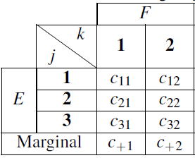

with
$$\lambda_1^E = \lambda_1^K = \lambda_{j1}^{EF} = \lambda_{1k}^{EF} = 0.$$
In the regression format, this expression equals the following
$$\begin{aligned}
\log\left(\mu_{jk}\right) = \xi_{0j} + \xi_{1j}F.
\end{aligned}$$

where $\xi_{0j}$ and $\xi_{1j}$ are the intercepts and the association of variable $F$ for each category $j$.

Note that the loglinear regression above can be written in the multiplication of matrix and vector as follow:
$$\begin{aligned}
\log\overbrace{\left(\begin{matrix}
\mu_{11}\\
\mu_{12}\\
\mu_{21}\\
\mu_{22}\\
\mu_{31}\\
\mu_{32}
\end{matrix}\right)}^{\text{LHS}} = \overbrace{\left(\begin{matrix}
1 & 0 & 0 & 0 & 0 & 0 \\
1 & 0 & 0 & 1 & 0 & 0 \\
1 & 1 & 0 & 0 & 0 & 0 \\
1 & 1 & 0 & 1 & 1 & 0 \\
1 & 0 & 1 & 0 & 0 & 0 \\
1 & 0 & 1 & 1 & 0 & 1
\end{matrix}
\right)}^{\text{Design matrix}}
\times
\left(\begin{matrix}
\lambda_0\\
\lambda_2^E\\
\lambda_3^E\\
\lambda_2^F\\
\lambda_{22}^{EF}\\
\lambda_{32}^{EF}
\end{matrix}\right)
\end{aligned}$$

The function `DesMat` returns the left hand side of the matrix multiplication and design matrix as described in the above equation. This can be done as follows:

```r
set.seed(12345)
Q <- 3; lvl.cov <- list(2);
FunDes <- DesMat(Q,lvl.cov)
FunDes
```

```
## $LHS
##   a b
## 1 1 1
## 2 2 1
## 3 3 1
## 4 1 2
## 5 2 2
## 6 3 2
##
## $Des.mat
##      l_0 a_2 a_3 b_2 ab_22 ab_32
## [1,]   1   0   0   0     0     0
## [2,]   1   1   0   0     0     0
## [3,]   1   0   1   0     0     0
## [4,]   1   0   0   1     0     0
## [5,]   1   1   0   1     1     0
## [6,]   1   0   1   1     0     1
```

From this, we could generate the dataset using R command `DataGen`. We need to specify the following variables `N,Q,S,theta,s.u, n.cov` which represents the number of subjects, the number of categories in the multinomial-type variable, the overdispersion parameter, the standard deviation for the random effect $u$ and the number of categorical covariates.

```r
N <- 100; Q <- 3; S = 2000; s.u = 0.88; theta = 0.2;
Des <- FunDes; lvl.cov <- list(2); n.cov <- 1; method = "DMM";
beta <- c(-1,0.1,0.5,0.8,-2)
SimDat <- DataGen(N = N, Q = Q, S = S,beta = beta, theta = theta, s.u = s.u, n.cov = n.cov, lvl.cov = lvl.cov, Des = Des, method = method)

head(SimDat)
```

| ID | C1 | C2 | C3 | X1 |
| --- | --- | --- | --- | --- |
| 1 | 833 | 848 | 319 | 2 |
| 2 | 713 | 1171 | 116 | 2 |
| 3 | 711 | 139 | 1150 | 1 |
| 4 | 818 | 1179 | 3 | 2 |
| 5 | 553 | 1317 | 130 | 2 |
| 6 | 679 | 1176 | 145 | 2 |

The data frame `SimDat` consists of 5 columns, in which the first column lists the subject’s IDs. The next three columns represents the count for three categorical outcome $C$ and the last column represents the binary categorical predictor $X$.

# The loglikelihood functions

The core function in this R package is the loglikelihood functions to estimate the regression parameters. The function `loglikcs` is used to obtain the estimates of the regression parameters where the correlation structure between repeated measurement is not accounted. Thus, the loglikelihood value from this function serves as null model in testing the random effect parameter (see Statistical Testing below). The function `logliklong` is used to estimate the regression parameters when the correlation structure is accounted.

For each loglikelihood functions, three different methods options can be used, i.e. `DMM`, `CNBM` or `UNBM`. In this tutorial, the `DMM` method will be used. The other methods work in a similar way.

We will illustrate the use of loglikelihood functions in this package to estimate the parameters of interests based on the generated dataset. We first use `loglikcs`, where the `log(s.u)` is ignored in the initial estimate `pars`.

```r
pars <- c(beta,log(theta))
Dat <- list("Y" = SimDat[,2:4],"X" = SimDat[,5])
ptm <- proc.time()
LLcs <- try(optim(pars,loglikcs, dataset = Dat, Des = FunDes, model = "DMM",method="BFGS",control=list(fnscale=-1,maxit = 5000,parscale=rep(1e-1,length(pars))),hessian=TRUE))
proc.time() - ptm
```

Then the `logliklong` is used to estimate the parameters of interest when correlation between repeated measurement is accounted.

```r
pars <- c(beta,log(s.u),log(theta))
Dat <- list("Y" = SimDat[,2:4],"X" = SimDat[,5])
ptm <- proc.time()
LLlong <- try(optim(pars,logliklong, dataset = Dat, Des = FunDes, model = "DMM",method="BFGS",control=list(fnscale=-1,maxit = 5000,parscale=rep(1e-1,length(pars))),hessian=TRUE))
proc.time() - ptm
```

The estimated fixed effect parameters as well as the estimated standard deviation of random effect and overdispersion for both loglikelihoods can be obtained in the following way :

```r
est.cs <- LLcs$par
est.long <- LLlong$par
```

# The standard errors for each parameters.

To calculate the standard error for each parameters we use the estimated Hessian obtained at the estimated parameters from loglikelihood function.

```r
Var.cs <- solve(-LLcs$hessian)
Var.long <- solve(-LLlong$hessian)
```

Thus, the estimated parameters and its standard error

```r
Tab.cs <- cbind("par" = est.cs, "SE" = sqrt(diag(Var.cs)))
Tab.long <- cbind("par" = est.long, "SE" = sqrt(diag(Var.long)))

rownames(Tab.cs) <- c(colnames(FunDes[[2]])[2:ncol(FunDes[[2]])],"log_theta")
rownames(Tab.long) <- c(colnames(FunDes[[2]])[2:ncol(FunDes[[2]])],"log(s.u)","log(theta)")

Tab.cs
```

```
##                   par         SE
## a_2       -1.04774948 0.10021303
## a_3        0.08352462 0.07634996
## b_2        0.92200846 0.15198404
## ab_22      0.82287467 0.11237327
## ab_32     -2.13543763 0.11844465
## log_theta -1.10793682 0.11086759
```

```r
Tab.long
```

```
##                   par         SE
## a_2        -1.0480159 0.09091129
## a_3         0.1217321 0.06730481
## b_2         0.8164126 0.17573665
## ab_22       0.8473934 0.10163961
## ab_32      -2.1370451 0.10903667
## log(s.u)   -0.4052953 0.16405703
## log(theta) -1.3649482 0.14335916
```

# Statistical Testing

## Statistical test for random effect parameters

We use the mixture of $\chi^2_{[0,1]}$ test to test the null hypothesis $H_0 : \sigma^2_u = 0 \text{ vs } H_1: \sigma^2 \neq 0$. This is done by performing the loglikelihood ratio test between the model without random effect and the loglikelihood with random effect.

```r
D <- -2*(LLcs$value - LLlong$value)
pchisq(D,df = 1,lower.tail =  FALSE)/2
```

```
## [1] 1.294692e-07
```

or using the built-in command `pchibarsq` inside the package `emdbook` as follows

```r
library(emdbook)
pchibarsq(D, df = 1, mix = 0.5, lower.tail=FALSE, log.p = FALSE)
```

```
## [1] 1.294692e-07
```

## Statistical test for fixed effect parameters

In the regression model used in this note, the fixed effects are intercept term and one covariate ($F$). The loglikelihood ratio test is used to test these parameters. To test the null hypothesis
$$H_0 : \xi_{1j} = 0, \text{for all }j$$
$$\text{ vs }$$
$$H_1 : \text{at least one } j, \xi_{1j} \neq 0$$

```r
VarName <- NULL
CN <- strsplit(colnames(FunDes[[2]]),"_")
for (i in 1:length(CN)){VarName[i] <- CN[[i]][1]}

idxsel <- which(VarName == "b"| VarName == "ab")

  Des1 <- FunDes[[2]][,-idxsel]
  FunDes1 <- list(FunDes[[1]],Des1)

pars <- est.long[-c(idxsel-1)]
ptm <- proc.time()
LLlong.cov <- try(optim(pars,logliklong, dataset = Dat, Des = FunDes1, model = "DMM",method="BFGS",control=list(fnscale=-1,maxit = 5000,parscale=rep(1e-1,length(pars))),hessian=TRUE))
proc.time() - ptm
```

The loglikelihood value for the null model (the model without covariate) is obtained from `LLlong.cov$value`.

Thus, the significance of the covariate $F$ can be obtained by the loglikelihood ratio test as follows.

```r
D <- -2*(LLlong.cov$value - LLlong$value)
pchisq(D,df = length(idxsel),lower.tail =  FALSE)
```

```
## [1] 1.785842e-84
```

# Other models

This note describe the generation of multivariate count data following Dirichlet-multinomial mixed model where the total count is fixed to be the same for all patients. To generate the multivariate count data when the total count for each patient varies, one could use `DataGen` function with `UNBM` model. To estimate the regression parameters, one could use the loglikelihood functions with all possible models in the similar manner as described above.

The loglikelihood functions in this package accounts for univariate random effect. In the case of more than one random effect, please refer to the package `JMoverCat` in the author’s github address.

# References

Martin, Ivonne, Hae-Won Uh, Taniawati Supali, Makedonka Mitreva, and Jeanine J. Houwing-Duistermaat. 2019. “The Mixed Model for the Analysis of a Repeated-Measurement Multivariate Count Data.” *Statistics in Medicine* 38 (12): 2248–68. https://doi.org/10.1002/sim.8101.